# Advanced Clustering Techniques

## Spectral Clustering

### Introduction

- Spectral clustering is a technique used in machine learning to group data into clusters that may not be linearly separable.
- It works by using the **eigenvalues** (spectra) of a **similarity matrix** of the data to perform dimensionality reduction before clustering in fewer dimensions.
- The method is particularly effective for identifying clusters that are connected through a graph structure but are not necessarily compact or evenly distributed in space.

Here’s a step-by-step breakdown of how spectral clustering works:

1. **Similarity Matrix Creation**: The first step involves creating a similarity matrix that represents how similar each pair of points in the dataset is to each other. This is often done using the Gaussian (RBF) kernel to convert the Euclidean distances between data points into similarity scores.

[figure not shown]

2. **Graph Representation**: The similarity matrix is then used to represent the data as a graph, with data points as nodes and the similarities as weights on the edges between nodes.

[figure not shown]

3. **Laplacian Matrix**: From this graph, a Laplacian matrix is computed. The Laplacian is a matrix representation that captures the structure of the graph. It is used to find the minimum number of cuts needed to partition the graph into clusters.

[figure not shown]

4. **Eigenvalue Decomposition**: The next step involves computing the eigenvalues and eigenvectors of the Laplacian matrix. The eigenvectors corresponding to the smallest eigenvalues (except for the smallest one, which is always zero) are used. These eigenvectors are then stacked to form a new dataset with reduced dimensions.

[figure not shown]

5. **Clustering**: The reduced dataset is then clustered using a conventional algorithm like k-means. Since the data is now in a space where clusters are more distinguishable, k-means or similar algorithms can effectively identify the clusters.

[figure not shown]

### What is a Similarity Matrix?

- The first step in spectral clustering, "Similarity Matrix Creation," is crucial as it lays the foundation for the entire clustering process. Let's delve into the details of this step.
- A **similarity matrix**, sometimes also referred to as an affinity matrix, is a *square matrix* used to represent the similarity between each pair of points in a dataset.
- In the context of spectral clustering, the dataset is typically comprised of multidimensional points, and **the goal is to measure how close or similar these points are to one another**.
- The similarity matrix is **symmetric**, with its diagonal elements representing the similarity of each point with itself (usually the maximum similarity score) and off-diagonal elements representing the similarity between different points.

**How is the Similarity Matrix Created?**

1. **Calculating Pairwise Distances**: The process begins by calculating the pairwise distances between all points in the dataset. This is often done using Euclidean distance, which measures the straight-line distance between two points in Euclidean space. However, other distance metrics can also be used depending on the nature of the data and the specific requirements of the clustering task.
2. **Converting Distances to Similarities**: Directly using distances as measures of similarity is not intuitive because in a similarity context, we expect similar points to have a high score. Hence, the distances need to be converted into similarity scores. This conversion is typically achieved using a similarity function, such as the Gaussian (Radial Basis Function, RBF) kernel.

**Using the Gaussian (RBF) Kernel**

The Gaussian kernel is a popular choice for transforming Euclidean distances into similarity scores. It is defined as follows:

$$ S(x, y) = \exp\left(-\frac{\|x - y\|^2}{2\sigma^2}\right) $$

- Here, $S(x, y)$ is the similarity between points $x$ and $y$, $\|x - y\|$ is the Euclidean distance between $x$ and $y$, and $\sigma$ is a parameter that controls the width of the neighborhood or the spread of the Gaussian kernel.
- The effect of this transformation is that points closer to each other (smaller distances) result in higher similarity scores (closer to 1), while points further apart have lower scores (closer to 0).

**Key Considerations**

- **Choice of $\sigma$**: The parameter $\sigma$ plays a crucial role in determining the scale of similarity. Choosing an appropriate $\sigma$ is essential for the success of the clustering.
  - *A small $\sigma$ makes the similarity drop off quickly with distance, leading to a sparser similarity matrix where only very close points are considered similar*.
  - *A larger $\sigma$ makes the similarity drop off more slowly, considering a broader range of points as similar*.
- **Sparsity of the Matrix**: In practice, for large datasets, the similarity matrix can be made sparse by setting all similarity scores below a certain threshold to zero. This reduces the computational complexity and focuses on stronger relationships, assuming that very distant points (low similarity) do not contribute significantly to the clustering structure.

The similarity matrix creation is a foundational step in spectral clustering that impacts the quality and characteristics of the resulting clusters. By carefully transforming distances into similarities, this step effectively captures the underlying structure of the data, setting the stage for identifying clusters based on the global relationships among data points.

### Graph Representation in Spectral Clustering

After creating the similarity matrix, which quantifies the similarity between every pair of data points in the dataset, the next step is to **interpret this matrix as a graph**.

In this context, a graph is a mathematical structure used to model pairwise relations between objects. This step is crucial for understanding the data's structure from a new perspective, enabling the application of graph theory concepts to identify clusters.

1. **Nodes (Vertices)**: Each data point in the dataset is represented as a node (or vertex) in the graph. If you have $N$ data points, the graph will have $N$ nodes.
2. **Edges**: Connections between nodes are called edges. In the context of spectral clustering, an edge is drawn between every pair of nodes. The existence of an edge between two nodes indicates that there is some level of similarity between the corresponding data points.
3. **Weights**: Each edge in the graph is assigned a weight that quantifies the strength of the connection (or similarity) between the two nodes it connects. These weights are directly taken from the similarity matrix. A higher weight indicates a stronger similarity between the nodes. In the case of using the Gaussian (RBF) kernel for generating the similarity matrix, the weights would reflect the Gaussian similarity between data points, with closer points having higher weights.

[figure not shown]

**Understanding the Constructed Graph**

- **Type of Graph**: The resulting graph is typically **undirected** since the similarity between two points is mutual. It is also **fully connected** because the similarity matrix provides a similarity score for every pair of points, implying an edge between every pair of nodes.
- **Sparsity and Thresholding**: Although the initial representation suggests a fully connected graph, in practice, the graph can be made sparse by removing edges with weights below a certain threshold, keeping only the most significant connections. This sparsification helps in reducing computational complexity and focusing on the most meaningful relationships in the data.
- **Interpretation**: The graph effectively models the dataset's structure, with clusters in the data expected to form tightly connected subgraphs. In other words, points within the same cluster are highly interconnected with strong edges (high weights), while points from different clusters have weaker connections (low weights or no edge at all).

**Role in Spectral Clustering**

- This graph representation is fundamental to spectral clustering because it allows the application of graph-theoretic algorithms to detect communities or clusters.
- The intuition is that cutting the graph into subgraphs (clusters) can be done in such a way that the connections (edges) between different clusters are weak (low similarity), while connections within a cluster are strong (high similarity).

[figure not shown]

### What is the Laplacian Matrix?

- Step 3 of the spectral clustering process involves the computation of the Laplacian matrix from the graph constructed in Step 2.
- In particular, the graph's structure is analyzed using eigendecomposition of the Laplacian matrix derived from the graph, which ultimately leads to the identification of clusters based on the spectral properties of the graph.
- This graph-based approach enables spectral clustering to identify clusters that may not be linearly separable and might have complex shapes, leveraging the topology of the data represented by the graph.
- The Laplacian matrix is a crucial concept in graph theory and spectral clustering, in a nutshell it is a matrix representation that captures the graph's structure, focusing on how nodes (data points) are connected to each other via edges (similarities).

**How is the Laplacian Matrix Computed?**

Given a graph $G$ with $N$ nodes, represented by its weighted adjacency matrix $W$ (**the similarity matrix from Step 1**), and a degree matrix $D$ (a diagonal matrix where each diagonal element $D_{ii}$ represents the sum of the weights of all edges connected to node $i$), the Laplacian matrix $L$ is computed as follows:

$$ L = D - W $$

Here’s what each component represents:

- **Weighted Adjacency Matrix ($W$)**: This matrix represents the graph, where each element $W_{ij}$ is the weight of the edge between nodes $i$ and $j$. If $i$ and $j$ are not directly connected, $W_{ij} = 0$.
- **Degree Matrix ($D$)**: This is a diagonal matrix where each entry $D_{ii}$ is the degree of node $i$, which, in the context of weighted graphs, is the **sum of the weights of all edges connected to node $i$**. In mathematical terms, $D_{ii} = \sum_{j} W_{ij}$.

[figure not shown]

**Variants of the Laplacian Matrix**

There are primarily two variants of the Laplacian matrix used in spectral clustering:

In these formulas, $I$ denotes the identity matrix.

**Role and Significance**

- **Capturing Graph Structure**: The Laplacian matrix highlights the differences in connectivity within the graph. It effectively captures how each node differs from its neighbors in terms of connectivity, which is essential for identifying separations or cuts in the graph.
- **Spectral Clustering**: The eigenvalues and eigenvectors of the Laplacian matrix reveal critical information about the graph's cluster structure. Specifically, the number of zero eigenvalues of $L$ corresponds to the number of connected components in the graph. **The eigenvectors associated with the smallest non-zero eigenvalues (known as Fiedler values) provide the means to partition the graph**. By analyzing these eigenvectors, spectral clustering algorithms can identify the minimum number of cuts needed to separate the graph into disjoint clusters, ensuring that the separation minimizes the similarity between different clusters while maximizing the similarity within clusters.
- **Partitioning**: The process of using the Laplacian's eigenvectors to partition the graph is based on the insight that these eigenvectors can serve as coordinates in a new space where clustering algorithms like k-means can be effectively applied to identify clusters.

### Eigenvalue Decomposition

In Step 4 the structural properties encoded in the Laplacian matrix are used to transform the data into a form where clusters can be easily identified. Remember that **Eigenvalue Decomposition** is a method of decomposing a matrix into its constituent parts in such a way that it reveals the matrix's intrinsic properties. For a square matrix $A$, the decomposition finds eigenvalues $\lambda$ and eigenvectors $v$ that satisfy the equation:

$$ A v = \lambda v $$

In the context of spectral clustering, $A$ is the Laplacian matrix $L$.

[figure not shown]

**Role in Spectral Clustering**

1. **Computing Eigenvalues and Eigenvectors**: The first step is to compute the eigenvalues and eigenvectors of the Laplacian matrix $L$. The eigenvalues give a spectrum that represents the graph's connectivity, and the corresponding eigenvectors provide directions along which the graph can be "cut" to form clusters.
2. **Selection of Eigenvectors**: The eigenvalues are sorted from smallest to largest. The smallest eigenvalue is typically zero (or close to zero for numerical reasons) and corresponds to a constant eigenvector (due to the graph's connectedness). This eigenvalue and its corresponding eigenvector are generally discarded because they do not contribute to distinguishing between clusters (see [this blog](https://medium.com/@roiyeho/spectral-clustering-50aee862d300) for a proof of this result).
3. **Dimensionality Reduction**: **The next few smallest eigenvalues and their corresponding eigenvectors are selected**. These eigenvectors are critical because they capture the most significant structure of the data as encoded in the graph. By stacking these eigenvectors column-wise, we form a new dataset. Each row of this new dataset represents the original data points, but now they are expressed in terms of these eigenvectors.
4. **Creating a Low-Dimensional Representation**: The process effectively transforms the original high-dimensional data into a lower-dimensional space. The dimensionality of this new space is determined by the number of selected eigenvectors. This transformed dataset is easier to cluster because the transformation has teased apart the clusters along the dimensions defined by the eigenvectors.

**Significance of the Eigenvectors**

- The selected eigenvectors serve as a basis for a new feature space where the clustering structure of the data is more apparent. Points that are part of the same cluster in the original space will be closer together in this new space, making traditional clustering techniques like k-means more effective.
- This transformation is possible because the eigenvectors corresponding to the smallest non-zero eigenvalues capture the slowest changes in the graph's connectivity. In other words, they highlight the broadest separations between clusters, where cutting the graph would incur the smallest "cost" in terms of disconnectedness.

**Practical Implications**

- This step is where the "spectral" in spectral clustering truly comes into play, as it leverages the spectrum (eigenvalues) of the Laplacian matrix to find a meaningful representation of the data. The process ensures that the inherent cluster structure, possibly obscured in the original high-dimensional space, becomes evident, facilitating the final clustering step.

### Clustering

This step is where the actual grouping of data points into clusters occurs. After transforming the dataset into a lower-dimensional space using the eigenvectors of the Laplacian matrix (as described in Step 4), the structure of the data is now more conducive to clustering.

**Preparing the Data for Clustering**

- **New Feature Space**: The eigenvectors selected in the previous step form a new dataset where each data point is represented in the reduced dimensional space. This space is constructed specifically to highlight the separation between clusters that was implicit in the original data's graph structure.
- **Rows as Points**: Each row of the new dataset (formed by stacking the selected eigenvectors) represents an original data point, but now encoded in terms of the principal components of the graph's structure. In this space, data points that belong to the same cluster in the original dataset are expected to be closer together, making them more distinguishable by clustering algorithms.

**Applying a Clustering Algorithm**

- **Choosing an Algorithm**: The most common algorithm used at this stage is k-means because of its simplicity and effectiveness. However, other clustering algorithms can also be applied depending on the specific characteristics of the data or the requirements of the task.
- **Number of Clusters**: The number of clusters, $k$, to be used by the clustering algorithm can be determined based on prior knowledge about the data, or by using methods such as the silhouette score, the elbow method, or other heuristic techniques to estimate the optimal $k$.
- **Execution**: The chosen clustering algorithm is applied to the dataset in the reduced dimensional space. Because the transformation has already enhanced the cluster structure, the algorithm can more easily identify and assign the data points to their respective clusters.

**Outcome**

- **Cluster Labels**: The result of this clustering step is a set of labels that indicate the cluster membership for each data point in the original dataset. These labels can then be used for further analysis, visualization, or as input for other machine learning tasks.
- **Interpretation**: The clusters identified in this lower-dimensional space correspond to groups of points that are similar according to the graph structure of the original data. This means that even if the original features did not clearly delineate clusters, the spectral clustering process has revealed the underlying structure.

**Significance**

This final step of clustering in the reduced dimensional space is significant because it leverages the preparatory work of transforming the data to make inherent clusters more apparent. By addressing the clustering problem in a space that explicitly reflects the connectivity and density of the original data, spectral clustering can uncover groupings that might be missed by applying traditional clustering algorithms directly to the original features.

**Practical Considerations**

- **Algorithm Parameters**: The effectiveness of this step can depend heavily on the choice of parameters for the clustering algorithm, such as the number of clusters and the initialization method for k-means.
- **Scalability**: While spectral clustering can provide superior results for complex cluster structures, the computational cost of earlier steps (especially eigenvalue decomposition) can limit its scalability to very large datasets.

### Purpose of Assignment Back to Original Data

The primary goal of this step is to integrate the clustering outcomes with the original dataset, making the results meaningful and applicable to real-world problems or further analysis. The clustering performed in the reduced dimensional space, while revealing the intrinsic structure of the data, abstracts away from the original features of the dataset. Therefore, assigning the discovered cluster memberships back to the original data points is crucial for interpretation and application.

**How the Assignment Works**

1. **Cluster Labels**: During the clustering phase in the reduced dimensional space, each data point is assigned a cluster label, indicating which cluster it belongs to. These labels are the key outcome of the clustering algorithm (e.g., k-means) used in the transformed space.
2. **Mapping Labels**: The cluster labels are directly mapped back to the corresponding data points in the original dataset. Since the rows of the transformed dataset represent the same data points as in the original dataset (albeit in a different feature space), this mapping is straightforward. Each data point in the original dataset is assigned the cluster label of its representation in the reduced dimensional space.
3. **Resulting Clustered Dataset**: The end result is the original dataset with an additional piece of information for each data point: its cluster membership. This allows for the clusters identified through spectral clustering to be analyzed and interpreted in the context of the original features and dimensions of the data.

### Examples of Spectral Clustering Applications

- **Image Segmentation**: Spectral clustering can be used to segment an image into regions based on the similarity of colors or textures. This is particularly useful in computer vision for object and boundary detection.
- **Social Network Analysis**: It can help identify communities within social networks by finding clusters of users that are more closely connected to each other than to the rest of the network.
- **Bioinformatics**: In gene expression data analysis, spectral clustering can be used to identify groups of genes that exhibit similar expression patterns, which may indicate a shared role in cellular processes.

Spectral clustering is powerful because it can identify complex cluster structures that traditional clustering algorithms might not detect. However, it also has its limitations, such as sensitivity to the choice of similarity measure and scalability issues with very large datasets.

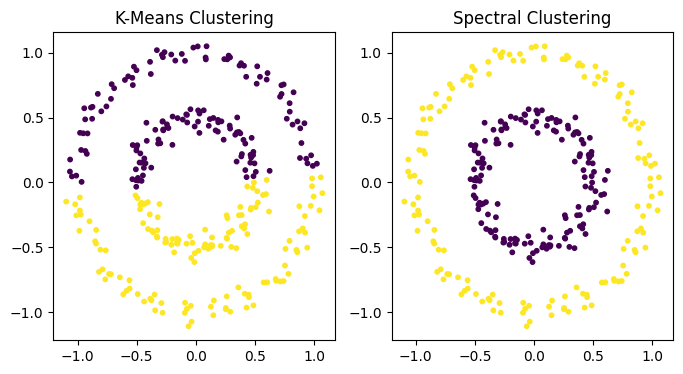

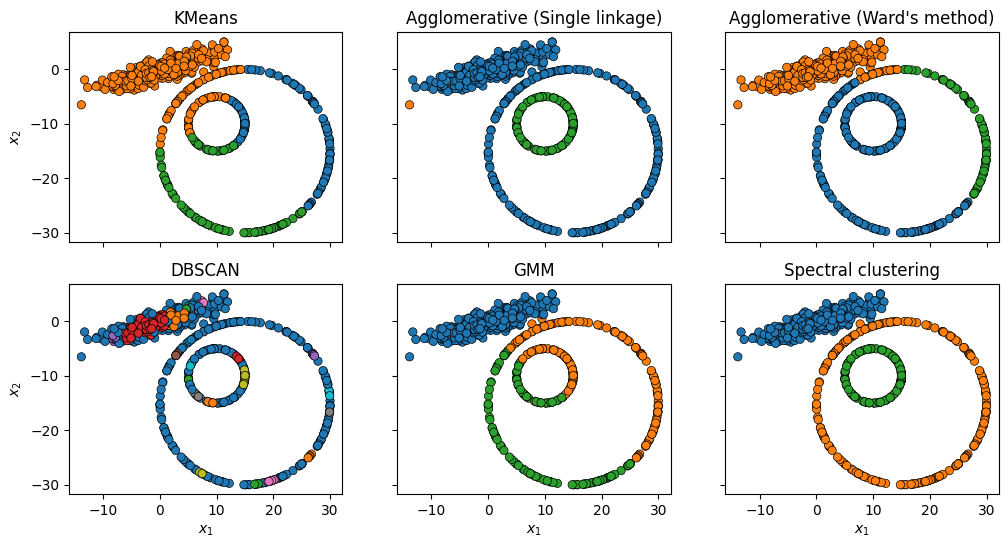

### Conclusions

**Advantages of Spectral Clustering**:

**Disadvantages of Spectral Clustering**:

- Complexity: Spectral clustering can be computationally expensive, especially for large datasets, as it requires the calculation of eigenvectors and eigenvalues.
- Model selection: Choosing the right number of clusters and the right similarity matrix can be challenging and may require expert knowledge or trial and error.

## Reference and Credits

[1] V. Gandhi, ["Spectral Clustering - Detailed Explanation"](https://www.kaggle.com/code/vipulgandhi/spectral-clustering-detailed-explanation)

[2] Roi Yehoshua, ["Spectral Clustering: Step-by-step derivation of the spectral clustering algorithm including an implementation in Python"](https://medium.com/@roiyeho/spectral-clustering-50aee862d300)

[3] A.Y. Ng, M.I. Jordan, Y. Weiss (2002). On spectral clustering: Analysis and an algorithm, Advances in neural information processing systems, pp. 849– 856.

[4] U. von Luxburg (2007), A Tutorial on Spectral Clustering, Statistics and computing, 17, 395–416.

[5] Lanczos, C. (1950). An iteration method for the solution of the eigenvalue problem of linear differential and integral operators, Journal of Research of the National Bureau of Standards. 45 (4): 255–282.

[6] Stoer, M., & Wagner, F. (1997). A simple min-cut algorithm. Journal of the ACM (JACM), 44(4), 585–591.

[7] Hagen, L., & Kahng, A. B. (1992). New spectral methods for ratio cut partitioning and clustering. IEEE transactions on computer-aided design of integrated circuits and systems, 11(9), 1074–1085.

[8] Fleshman, W. - ["Spectral Clustering Foundation and Application"](https://towardsdatascience.com/spectral-clustering-aba2640c0d5b), Published in Towards Data Science Feb 21, 2019.